# ds-ua-112-lab03

## Lab 3: Pandas Overview **This assignment should be completed by Sunday September 22, 2019 at 11:59 PM.**

[Pandas](https://pandas.pydata.org/) is one of the most widely used Python libraries in data science. In this lab, you will learn commonly used data wrangling operations/tools in Pandas. We aim to give you familiarity with:

- Creating dataframes
- Slicing data frames (i.e. selecting rows and columns)
- Filtering data (using boolean arrays)

In this lab you are going to use several pandas methods, such as `drop` and `loc`. You may press `shift+tab` on the method parameters to see the documentation for that method.

**Note**: The Pandas interface is confusing. Throughout the semester, you will have to search through Pandas documentation and experiment, but remember it is part of the learning experience.

```python
import numpy as np
import matplotlib.pyplot as plt
import pandas as pd
%matplotlib inline
```

## Creating DataFrames & Basic Manipulations

A dataframe is a table in which each column has a type; there is an index over the columns (typically string labels) and an index over the rows (typically ordinal numbers).

The pandas `DataFrame` class ([docs](https://pandas.pydata.org/pandas-docs/stable/generated/pandas.DataFrame.html) provides at least two syntaxes to create a data frame.

**Syntax 1:** You can create a data frame by specifying the columns and values using a dictionary as shown below.

The keys of the dictionary are the column names, and the values of the dictionary are lists containing the row entries.

```python
fruit_info = pd.DataFrame(
    data={'fruit': ['apple', 'orange', 'banana', 'raspberry'],
          'color': ['red', 'orange', 'yellow', 'pink']
          })
fruit_info
```

|  | fruit | color |
| --- | --- | --- |
| 0 | apple | red |
| 1 | orange | orange |
| 2 | banana | yellow |
| 3 | raspberry | pink |

**Syntax 2:** You can also define a dataframe by specifying the rows like below.

Each row corresponds to a distinct tuple, and the columns are specified separately.

```python
fruit_info2 = pd.DataFrame(
    [("red", "apple"), ("orange", "orange"), ("yellow", "banana"),
     ("pink", "raspberry")],
    columns = ["color", "fruit"])
fruit_info2
```

|  | color | fruit |
| --- | --- | --- |
| 0 | red | apple |
| 1 | orange | orange |
| 2 | yellow | banana |
| 3 | pink | raspberry |

You can obtain the dimensions of a dataframe by using the shape attribute dataframe.shape

```python
fruit_info.shape
```

```
(4, 2)
```

You can also convert the entire dataframe into a two-dimensional numpy array.

```python
fruit_info.values
```

```
array([['apple', 'red'],
       ['orange', 'orange'],
       ['banana', 'yellow'],
       ['raspberry', 'pink']], dtype=object)
```

### Question 1(a)

For a DataFrame `d`, you can add a column by `d['new column name'] = ...` and assigning a list or array of values to the column. Add a column of integers containing 1, 2, 3, and 4 called `rank1` to the `fruit_info` table which expresses your personal preference about the taste ordering for each fruit (1 is tastiest; 4 is least tasty).

```
BEGIN QUESTION
name: q1a
```

```python
# BEGIN SOLUTION
# TODO
# END SOLUTION
fruit_info["rank1"] = [1,2,3,4]
fruit_info
```

|  | fruit | color | rank1 |
| --- | --- | --- | --- |
| 0 | apple | red | 1 |
| 1 | orange | orange | 2 |
| 2 | banana | yellow | 3 |
| 3 | raspberry | pink | 4 |

```python
# TEST
# EXPECTED: dtype('int64')
fruit_info["rank1"].dtype
```

```
dtype('int64')
```

```python
# TEST
# EXPECTED: [1, 2, 3, 4]
sorted(fruit_info["rank1"].dropna())
```

```
[1, 2, 3, 4]
```

### Question 1(b)

You can also add a column to `d` by `d.loc[:, 'new column name'] = ...`. This way to modify an existing dataframe is faster and therefore preferred over the assignment syntax above. We will explain in more detail what `loc[]` does, but essentially the first parameter is for the rows and second is for columns. The `:` means change all rows and the `new column name` indicates the index value of the column you are modifying (or in this case, adding).

Add a column called `rank2` to the `fruit_info` table which contains the same values in the same order as the `rank1` column.

```
BEGIN QUESTION
name: q1b
```

```python
# BEGIN SOLUTION
# TODO
# END SOLUTION
fruit_info.loc[:, 'rank2'] = [1,2,3,4]
```

```python
# TEST
# EXPECTED: dtype('int64')
fruit_info["rank2"].dtype
```

```
dtype('int64')
```

```python
# TEST
# EXPECTED:
"""
0    True
1    True
2    True
3    True
dtype: bool
"""
fruit_info["rank2"] == fruit_info["rank1"]
```

```
0    True
1    True
2    True
3    True
dtype: bool
```

### Question 2

Use the `.drop()` method to [drop](https://pandas.pydata.org/pandas-docs/stable/generated/pandas.DataFrame.drop.html) the both the `rank1` and `rank2` columns you created. (Make sure to use the `axis` parameter correctly.) Note that `drop` does not change a table, but instead returns a new table with fewer columns or rows unless you set the optional `inplace` parameter.

*Hint*: Look through the documentation to see how you can drop multiple columns of a Pandas dataframe at once using a list of column names.

```
BEGIN QUESTION
name: q2
```

```python
# BEGIN SOLUTION
# TODO
# END SOLUTION
fruit_info_original = fruit_info.drop(axis=0, index=None, columns=['rank1', 'rank2'])
```

```python
# TEST
# EXPECTED: (4, 2)
fruit_info_original.shape
```

```
(4, 2)
```

```python
# TEST
# EXPECTED: (4, 4)
fruit_info.shape
```

```
(4, 4)
```

```python
# TEST
# EXPECTED: Index(['fruit', 'color'], dtype='object')
fruit_info_original.columns
```

```
Index(['fruit', 'color'], dtype='object')
```

### Question 3

Use the `.rename()` method to [rename](https://pandas.pydata.org/pandas-docs/stable/generated/pandas.DataFrame.rename.html) the columns of `fruit_info_original` so they begin with capital letters. Set the `inplace` parameter correctly to change the `fruit_info_original` dataframe.

```
BEGIN QUESTION
name: q3
```

```python
# BEGIN SOLUTION
columns={"A": "a", "B": "c"}
# TODO
# END SOLUTION
fruit_info_original.rename(columns={"fruit": "Fruit", "color":"Color", "rank1": "Rank1", "rank2": "Rank2"}, inplace=True)
```

```python
# TEST
# EXPECTED: Index(['Fruit', 'Color'], dtype='object')
fruit_info_original.columns
```

```
Index(['Fruit', 'Color'], dtype='object')
```

```python
# TEST
# EXPECTED: Index(['fruit', 'color', 'rank1', 'rank2'], dtype='object')
fruit_info.columns
```

```
Index(['fruit', 'color', 'rank1', 'rank2'], dtype='object')
```

### Babyname datasets

Now that we have learned the basics, let's move on to the babynames dataset. The babynames dataset contains a record of the given names of babies born in the United States each year.

### `fetch_and_cache` Helper

The following function downloads and caches data in the `data/` directory and returns the `Path` to the downloaded file. The cell below the function describes how it works.

```python
import requests
from pathlib import Path

def fetch_and_cache(data_url, file, data_dir="data", force=False):
    """
    Download and cache a url and return the file object.

    data_url: the web address to download
    file: the file in which to save the results.
    data_dir: (default="data") the location to save the data
    force: if true the file is always re-downloaded

    return: The pathlib.Path to the file.
    """
    data_dir = Path(data_dir)
    data_dir.mkdir(exist_ok=True)
    file_path = data_dir/Path(file)
    if force and file_path.exists():
        file_path.unlink()
    if force or not file_path.exists():
        print('Downloading...', end=' ')
        resp = requests.get(data_url)
        with file_path.open('wb') as f:
            f.write(resp.content)
        print('Done!')
    else:
        import time
        created = time.ctime(file_path.stat().st_ctime)
        print("Using cached version downloaded at", created)
    return file_path
```

In Python, a `Path` object represents the filesystem paths to files (and other resources). The `pathlib` module is effective for writing code that works on different operating systems and filesystems.

To check if a file exists at a path, use `.exists()`. To create a directory for a path, use `.mkdir()`. To remove a file that might be a [symbolic link](https://en.wikipedia.org/wiki/Symbolic_link), use `.unlink()`.

This function creates a path to a directory that will contain data files. It ensures that the directory exists (which is required to write files in that directory), then proceeds to download the file based on its URL.

The benefit of this function is that not only can you force when you want a new file to be downloaded using the `force` parameter, but in cases when you don't need the file to be re-downloaded, you can use the cached version and save download time.

Below we use `fetch_and_cache` to download the `namesbystate.zip` zip file, which is a compressed directory of CSV files.

**This might take a little while! Consider stretching.**

```python
data_url = 'https://www.ssa.gov/oact/babynames/state/namesbystate.zip'
namesbystate_path = fetch_and_cache(data_url, 'namesbystate.zip')
```

```
Using cached version downloaded at Sat Sep 28 12:16:41 2019
```

*Optional Hacking Challenge:* Use the `zipfile` module, `pd.read_csv`, and `pd.concat` to build a single dateframe called `baby_names` containing all of the data from each state with the `column_labels` below. a `ZipFile` object has an attribute `filelist` and a method `open`. Each `.TXT` file inside `namesbystate.zip` is a CSV file for the names of babies born in one state.

If you don't want to figure out how to read a zip file, you can just scroll down and use the cell where we've done it for you.

```python
import zipfile
zf = zipfile.ZipFile(namesbystate_path, 'r')
#Zipfile.open(namesbystate.zip)
#zf.read_csv
column_labels = ['State', 'Sex', 'Year', 'Name', 'Count']
#baby_names = pd.concat(column_labels)

...
```

```
Ellipsis
```

The following cell builds the final full `baby_names` DataFrame. It first builds one dataframe per state, because that's how the data are stored in the zip file. Here is documentation for [pd.concat](https://pandas.pydata.org/pandas-docs/version/0.22/generated/pandas.concat.html) if you want to know more about its functionality.

```python
import zipfile
zf = zipfile.ZipFile(namesbystate_path, 'r')

column_labels = ['State', 'Sex', 'Year', 'Name', 'Count']

def load_dataframe_from_zip(zf, f):
    with zf.open(f) as fh:
        return pd.read_csv(fh, header=None, names=column_labels)

states = [
    load_dataframe_from_zip(zf, f)
    for f in sorted(zf.filelist, key=lambda x:x.filename)
    if f.filename.endswith('.TXT')
]

baby_names = states[0]
for state_df in states[1:]:
    baby_names = pd.concat([baby_names, state_df])
baby_names = baby_names.reset_index().iloc[:, 1:]
```

```python
len(baby_names)
```

```
6028151
```

```python
baby_names.head()
```

|  | State | Sex | Year | Name | Count |
| --- | --- | --- | --- | --- | --- |
| 0 | AK | F | 1910 | Mary | 14 |
| 1 | AK | F | 1910 | Annie | 12 |
| 2 | AK | F | 1910 | Anna | 10 |
| 3 | AK | F | 1910 | Margaret | 8 |
| 4 | AK | F | 1910 | Helen | 7 |

## Slicing Data Frames - selecting rows and columns

### Selection Using Label/Index (using loc)

**Column Selection** To select a column of a `DataFrame` by column label, the safest and fastest way is to use the `.loc` [method](https://pandas.pydata.org/pandas-docs/stable/generated/pandas.DataFrame.loc.html). General usage looks like `df.loc[rowname,colname]`. (Reminder that the colon `:` means "everything"). For example, if we want the `color` column of the `ex` data frame, we would use : `ex.loc[:, 'color']`

- You can also slice across columns. For example, `baby_names.loc[:, 'Name':]` would give select the columns `Name` and the columns after.
- *Alternative:* While `.loc` is invaluable when writing production code, it may be a little too verbose for interactive use. One recommended alternative is the `[]` method, which takes on the form `df['colname']`.

**Row Selection** Similarly, if we want to select a row by its label, we can use the same `.loc` method. In this case, the "label" of each row refers to the index (ie. primary key) of the dataframe.

```python
#Example:
baby_names.loc[2:5, 'Name']
```

```
2        Anna
3    Margaret
4       Helen
5       Elsie
Name: Name, dtype: object
```

```python
#Example:  Notice the difference between these two methods
baby_names.loc[2:5, ['Name']]
```

|  | Name |
| --- | --- |
| 2 | Anna |
| 3 | Margaret |
| 4 | Helen |
| 5 | Elsie |

The `.loc` actually uses the Pandas row index rather than row id/position of rows in the dataframe to perform the selection. Also, notice that if you write `2:5` with `loc[]`, contrary to normal Python slicing functionality, the end index is included, so you get the row with index 5.

### Selection using Integer location (using iloc)

There is another Pandas slicing function called `iloc[]` which lets you slice the dataframe by row position and column position instead of by row index and column label (for `loc[]`). This is really the main difference between the 2 functions and it is **important** that you remember the difference and why you might want to use one over the other. In addition, with `iloc[]`, the end index is NOT included, like with normal Python slicing.

Below, we have sorted the `baby_names` dataframe. Notice how the *position* of a row is not necessarily equal to the *index* of a row. For example, the first row is not necessarily the row associated with index 1. This distinction is important in understanding the different between `loc[]` and `iloc[]`.

```python
sorted_baby_names = baby_names.sort_values(by=['Name'])
sorted_baby_names.head()
```

|  | State | Sex | Year | Name | Count |
| --- | --- | --- | --- | --- | --- |
| 4116672 | NY | M | 2013 | Aaban | 6 |
| 4118755 | NY | M | 2014 | Aaban | 6 |
| 730477 | CA | M | 2008 | Aadan | 7 |
| 748471 | CA | M | 2014 | Aadan | 5 |
| 5392325 | TX | M | 2008 | Aadan | 5 |

Here is an example of how we would get the 2nd, 3rd, and 4th rows with only the `Name` column of the `baby_names` dataframe using both `iloc[]` and `loc[]`. Observe the difference, especially after sorting `baby_names` by name.

```python
sorted_baby_names.iloc[1:4, 3]
```

```
4118755    Aaban
730477     Aadan
748471     Aadan
Name: Name, dtype: object
```

Notice that using `loc[]` with 1:4 gives different results, since it selects using the *index*.

```python
sorted_baby_names.loc[1:4, ['Name']]
```

|  | Name |
| --- | --- |
| 1 | Annie |
| 2141623 | Annie |
| 65626 | Annie |
| 5940084 | Annie |
| 2474948 | Annie |
| 1424901 | Annie |
| 1711337 | Annie |
| 2688882 | Annie |
| 321960 | Annie |
| 5130308 | Annie |
| 972043 | Annie |
| 2277550 | Annie |
| 416814 | Annie |
| 2364495 | Annie |
| 2930520 | Annie |
| 1513472 | Annie |
| 5221526 | Annie |
| 2246436 | Annie |
| 3559008 | Annie |
| 279819 | Annie |
| 4775850 | Annie |
| 2819293 | Annie |
| 950950 | Annie |
| 1270797 | Annie |
| 786683 | Annie |
| 3990711 | Annie |
| 2503095 | Annie |
| 883438 | Annie |
| 2108698 | Annie |
| 2635418 | Annie |
| ... | ... |
| 899210 | Helen |
| 4182634 | Helen |
| 181991 | Helen |
| 3558395 | Helen |
| 4473175 | Helen |
| 2120072 | Helen |
| 4785433 | Helen |
| 2840248 | Helen |
| 949751 | Helen |
| 3852890 | Helen |
| 2824885 | Helen |
| 4593916 | Helen |
| 4943647 | Helen |
| 795347 | Helen |
| 2135780 | Helen |
| 4618326 | Helen |
| 2018309 | Helen |
| 3189674 | Helen |
| 2504895 | Helen |
| 2709643 | Helen |
| 4941184 | Helen |
| 3459618 | Helen |
| 5437047 | Helen |
| 4986937 | Helen |
| 1949 | Helen |
| 1524359 | Helen |
| 5846263 | Helen |
| 264296 | Helen |
| 2598349 | Helen |
| 4 | Helen |

2042507 rows × 1 columns

Lastly, we can change the index of a dataframe using the `set_index` method.

```python
#Example: We change the index from 0,1,2... to the Name column
df = baby_names[:5].set_index("Name")
df
```

| Name | State | Sex | Year | Count |
| --- | --- | --- | --- | --- |
| Mary | AK | F | 1910 | 14 |
| Annie | AK | F | 1910 | 12 |
| Anna | AK | F | 1910 | 10 |
| Margaret | AK | F | 1910 | 8 |
| Helen | AK | F | 1910 | 7 |

We can now lookup rows by name directly:

```python
df.loc[['Mary', 'Anna'], :]
```

| Name | State | Sex | Year | Count |
| --- | --- | --- | --- | --- |
| Mary | AK | F | 1910 | 14 |
| Anna | AK | F | 1910 | 10 |

However, if we still want to access rows by location we will need to use the integer loc (`iloc`) accessor:

```python
#Example:
#df.loc[2:5,"Year"] You can't do this
df.iloc[1:4,2:3]
```

| Name | Year |
| --- | --- |
| Annie | 1910 |
| Anna | 1910 |
| Margaret | 1910 |

### Question 4

Selecting multiple columns is easy. You just need to supply a list of column names. Select the `Name` and `Year` **in that order** from the `baby_names` table.

```
BEGIN QUESTION
name: q4
```

```python
# BEGIN SOLUTION
# TODO
# END SOLUTION
name_and_year = baby_names.loc[:, ['Name', 'Year']]
name_and_year[:5]
```

|  | Name | Year |
| --- | --- | --- |
| 0 | Mary | 1910 |
| 1 | Annie | 1910 |
| 2 | Anna | 1910 |
| 3 | Margaret | 1910 |
| 4 | Helen | 1910 |

```python
# TEST
# EXPECTED: (5933561, 2)
name_and_year.shape
```

```
(6028151, 2)
```

```python
# TEST
# EXPECTED: 'Mary'
name_and_year.loc[0,"Name"]
```

```
'Mary'
```

```python
# TEST
# EXPECTED: 1910
name_and_year.loc[0,"Year"]
```

```
1910
```

Note that `.loc[]` can be used to re-order the columns within a dataframe.

## Filtering Data

### Filtering with boolean arrays

Filtering is the process of removing unwanted material. In your quest for cleaner data, you will undoubtedly filter your data at some point: whether it be for clearing up cases with missing values, for culling out fishy outliers, or for analyzing subgroups of your data set. Note that compound expressions have to be grouped with parentheses. Example usage looks like `df[df['column name'] < 5]]`.

For your reference, some commonly used comparison operators are given below.

| Symbol | Usage | Meaning |
| --- | --- | --- |
| == | a == b | Does a equal b? |
| <= | a <= b | Is a less than or equal to b? |
| >= | a >= b | Is a greater than or equal to b? |
| < | a < b | Is a less than b? |
| > | a > b | Is a greater than b? |
| ~ | ~p | Returns negation of p |
| \| | p \| q | p OR q |
| & | p & q | p AND q |
| ^ | p ^ q | p XOR q (exclusive or) |

In the following we construct the DataFrame containing only names registered in California

```python
ca = baby_names[baby_names['State'] == 'CA']
ca
```

|  | State | Sex | Year | Name | Count |
| --- | --- | --- | --- | --- | --- |
| 379228 | CA | F | 1910 | Mary | 295 |
| 379229 | CA | F | 1910 | Helen | 239 |
| 379230 | CA | F | 1910 | Dorothy | 220 |
| 379231 | CA | F | 1910 | Margaret | 163 |
| 379232 | CA | F | 1910 | Frances | 134 |
| 379233 | CA | F | 1910 | Ruth | 128 |
| 379234 | CA | F | 1910 | Evelyn | 126 |
| 379235 | CA | F | 1910 | Alice | 118 |
| 379236 | CA | F | 1910 | Virginia | 101 |
| 379237 | CA | F | 1910 | Elizabeth | 93 |
| 379238 | CA | F | 1910 | Florence | 93 |
| 379239 | CA | F | 1910 | Marie | 90 |
| 379240 | CA | F | 1910 | Mildred | 90 |
| 379241 | CA | F | 1910 | Rose | 74 |
| 379242 | CA | F | 1910 | Hazel | 68 |
| 379243 | CA | F | 1910 | Louise | 67 |
| 379244 | CA | F | 1910 | Josephine | 66 |
| 379245 | CA | F | 1910 | Lucille | 66 |
| 379246 | CA | F | 1910 | Grace | 65 |
| 379247 | CA | F | 1910 | Gladys | 63 |
| 379248 | CA | F | 1910 | Edna | 62 |
| 379249 | CA | F | 1910 | Eleanor | 60 |
| 379250 | CA | F | 1910 | Marjorie | 60 |
| 379251 | CA | F | 1910 | Bernice | 59 |
| 379252 | CA | F | 1910 | Thelma | 59 |
| 379253 | CA | F | 1910 | Edith | 58 |
| 379254 | CA | F | 1910 | Doris | 56 |
| 379255 | CA | F | 1910 | Irene | 56 |
| 379256 | CA | F | 1910 | Lillian | 55 |
| 379257 | CA | F | 1910 | Catherine | 53 |
| ... | ... | ... | ... | ... | ... |
| 760412 | CA | M | 2018 | Tylin | 5 |
| 760413 | CA | M | 2018 | Uzziel | 5 |
| 760414 | CA | M | 2018 | Valerian | 5 |
| 760415 | CA | M | 2018 | Vedh | 5 |
| 760416 | CA | M | 2018 | Vian | 5 |
| 760417 | CA | M | 2018 | Vibhav | 5 |
| 760418 | CA | M | 2018 | Vinson | 5 |
| 760419 | CA | M | 2018 | Vishnu | 5 |
| 760420 | CA | M | 2018 | Wali | 5 |
| 760421 | CA | M | 2018 | Wayde | 5 |
| 760422 | CA | M | 2018 | Waylan | 5 |
| 760423 | CA | M | 2018 | Westyn | 5 |
| 760424 | CA | M | 2018 | Willian | 5 |
| 760425 | CA | M | 2018 | Xavien | 5 |
| 760426 | CA | M | 2018 | Yasmani | 5 |
| 760427 | CA | M | 2018 | Yehuda | 5 |
| 760428 | CA | M | 2018 | Younes | 5 |
| 760429 | CA | M | 2018 | Yovani | 5 |
| 760430 | CA | M | 2018 | Yuto | 5 |
| 760431 | CA | M | 2018 | Yuven | 5 |
| 760432 | CA | M | 2018 | Zackery | 5 |
| 760433 | CA | M | 2018 | Zak | 5 |
| 760434 | CA | M | 2018 | Zaki | 5 |
| 760435 | CA | M | 2018 | Zaylen | 5 |
| 760436 | CA | M | 2018 | Zayvion | 5 |
| 760437 | CA | M | 2018 | Zed | 5 |
| 760438 | CA | M | 2018 | Zein | 5 |
| 760439 | CA | M | 2018 | Zhaire | 5 |
| 760440 | CA | M | 2018 | Zidane | 5 |
| 760441 | CA | M | 2018 | Zuriel | 5 |

381214 rows × 5 columns

### Question 5

Select the names in Year 2000 (for all baby_names) that have larger than 3000 counts. What do you notice?

(If you use `p & q` to filter the dataframe, make sure to use `df[df[(p) & (q)]]` or `df.loc[df[(p) & (q)]])`

**Remember** that both slicing and `loc` will achieve the same result, it is just that `loc` is typically faster in production. You are free to use whichever one you would like.

```
BEGIN QUESTION
name: q5
```

```python
# BEGIN SOLUTION
# TODO
# END SOLUTION
result = baby_names.loc[(baby_names['Count'] > 3000) & (baby_names['Year'] == 2000)]
result.head()
```

|  | State | Sex | Year | Name | Count |
| --- | --- | --- | --- | --- | --- |
| 706923 | CA | M | 2000 | Daniel | 4341 |
| 706924 | CA | M | 2000 | Anthony | 3838 |
| 706925 | CA | M | 2000 | Jose | 3803 |
| 706926 | CA | M | 2000 | Andrew | 3600 |
| 706927 | CA | M | 2000 | Michael | 3572 |

```python
# TEST
# EXPECTED: 11
len(result)
```

```
11
```

```python
# TEST
# EXPECTED: 38993
result["Count"].sum()
```

```
38997
```

```python
# TEST
# EXPECTED: 4339
result["Count"].iloc[0]
```

```
4341
```

### Question 6

Some names gain/lose popularity because of cultural phenomena such as a political figure coming to power. Below, we plot the popularity of the name Hillary over time. What do you notice about this plot? What might be the cause of the steep drop?

```
BEGIN QUESTION
name: q6
```

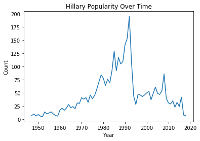

```python
hillary_baby_name = baby_names[(baby_names['Name'] == 'Hillary') & (baby_names['State'] == 'CA') &(baby_names['Sex'] == 'F')]
plt.plot(hillary_baby_name['Year'], hillary_baby_name['Count'])
plt.title("Hillary Popularity Over Time")
plt.xlabel('Year')
plt.ylabel('Count');
```

ANSWER: As said before: Some names gain/lose popularity because of cultural phenomena such as a political figure coming to power.

Based on the plot, the popularity (in terms of count of children named Hillary) decreases drastically, almost a complete drop. The steep droop is caused by the unpopularity of Hillary Clinton to some people. It also goes without saying that the name spiked in popularity in the 1990's era, then drastically dropped afterwards.